# PROYECTO

Claribel Santiago

2023-05-25

```r
knitr::opts_chunk$set(echo = TRUE)
library(VIM)
library(mice)#imputar
library(dplyr)
library(ggcorrplot)#matrices de correlaciones y distancias
library(corrplot)#matrices de correlaciones y distancias}
library(aplpack)#CARITAS DE CHERNOFF
library(lattice)#GRÁFICO DE PARALELAS
library(RColorBrewer)
library(purrr)
library(kableExtra)
```

## BASE DE DATOS

- Cargamos las bases de datos *heroesInformation* y *characterStats*. Quitamos los nombres duplicados y unimos *DC_Marvel* con *infoStats* según sus nombres.

```r
infoHeroes <- read.csv("~/PROYECTO-CLARIBEL/Data/heroesInformation.csv", na.strings = c("-", "-99", "-99.0"))
infoStats <- read.csv("~/PROYECTO-CLARIBEL/Data/charactersStats.csv", na.strings = "")
colnames(infoHeroes)[2] <- "Name"

DC_Marvel <- infoHeroes %>%
  filter(infoHeroes$Publisher %in% c("DC Comics", "Marvel Comics"))

duplicated(DC_Marvel$Name)
dim(DC_Marvel)
DC_Marvel <- DC_Marvel %>%
  filter(!duplicated(Name))

Dc_Marvel_StatsInfo <- left_join(DC_Marvel, infoStats, by = "Name")
```

- Usamos la función aggr() para calcular resúmenes estadísticos para subconjuntos de datos. En particular, queremos calcular los NA en nuestra base de datos.

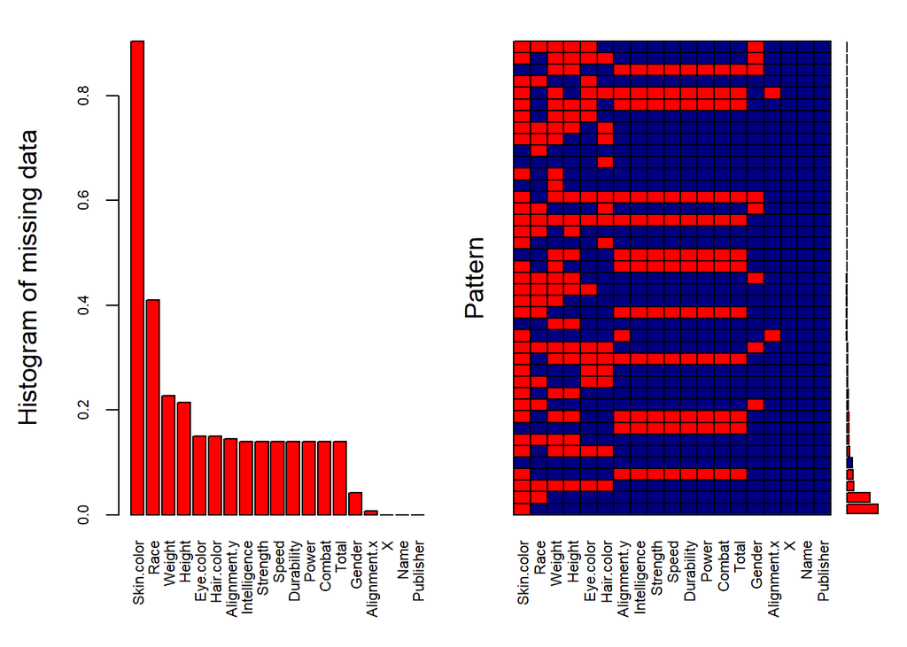

```r
aggr_plot <- aggr(Dc_Marvel_StatsInfo, col=c('navyblue','red'), numbers=TRUE, sortVars=TRUE, labels=names(Dc_Marvel_StatsInfo),
                 cex.axis=.7, gap=3, ylab=c("Histogram of missing data","Pattern"))
```

```r
Dc_Marvel_StatsInfo<-Dc_Marvel_StatsInfo[,-19]#SE MODIFICARÁ AL IMPUTAR
Dc_Marvel_StatsInfo <- Dc_Marvel_StatsInfo[,-12]#ESTÁ REPETIDO
Dc_Marvel_StatsInfo <- Dc_Marvel_StatsInfo[,-9]#ES LA COLUMNA CON MÁS NA
Dc_Marvel_StatsInfo<-Dc_Marvel_StatsInfo[,-1]#NO SABEMOS QUE SIGNIFICA X
```

- Para no reducir tanto la base de datos, cambiamos los valores con NA de las columnas no numéricas por “Undefined”.

```r
Dc_Marvel_StatsInfo$Race[is.na(Dc_Marvel_StatsInfo$Race)] <- "Undefined"
Dc_Marvel_StatsInfo$Eye.color[is.na(Dc_Marvel_StatsInfo$Eye.color)] <- "Undefined"
Dc_Marvel_StatsInfo$Alignment.x[is.na(Dc_Marvel_StatsInfo$Alignment.x)] <- "Undefined"
Dc_Marvel_StatsInfo$Hair.color[is.na(Dc_Marvel_StatsInfo$Hair.color)] <- "Undefined"
Dc_Marvel_StatsInfo$Gender[is.na(Dc_Marvel_StatsInfo$Gender)] <- "Undefined"
```

- Los datos faltantes son
  - *Completatemente aleatorios* si la razón de la falta de datos es ajena a los datos mismos es decir, no depende de la categoría del resto de las variables.
  - *No aleatorios* si no son completamente aleatorios.
  - *Aleatorio* si no depende de las categorías pero si puede depender de otras variables.

Como todos los datos faltantes que nos quedan son Aleatorios o completamente aleatorios usamos el método de imputación de datos. Idealmente, queremos no cambiar la distribución de nuestros datos.

*Imputación con la media*: N=Antes de la imputación, R=con la imputación.

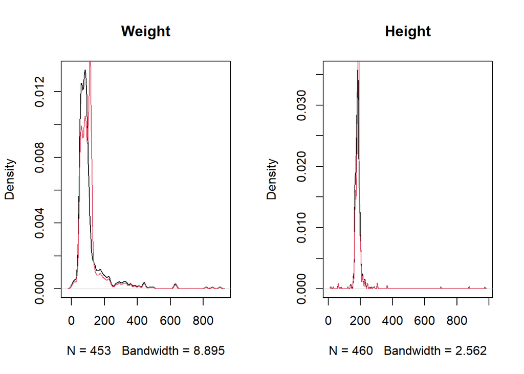

```r
# https://rpubs.com/ydmarinb/429757
columns <- c("Weight", "Height")
imputed_data <- mice(Dc_Marvel_StatsInfo[,names(Dc_Marvel_StatsInfo) %in% columns],m = 1,
  maxit = 1, method = "mean",seed = 2018,print=F)
complete.data <- mice::complete(imputed_data)
par(mfrow=c(1,2))
plot(density(Dc_Marvel_StatsInfo$Weight,na.rm = T),col=1,main="Weight")
lines(density(complete.data$Weight),col=2)
plot(density(Dc_Marvel_StatsInfo$Height,na.rm = T),col=1,main="Height")
lines(density(complete.data$Height),col=2)
```

```r
impute_arg<-round(as.data.frame(complete.data))

Dc_Marvel_StatsInfo["Weight"]<-impute_arg["Weight"]
Dc_Marvel_StatsInfo["Height"]<-impute_arg["Height"]
```

*Imputación mediante regresión*: N=Antes de la imputación, R=con la imputación.

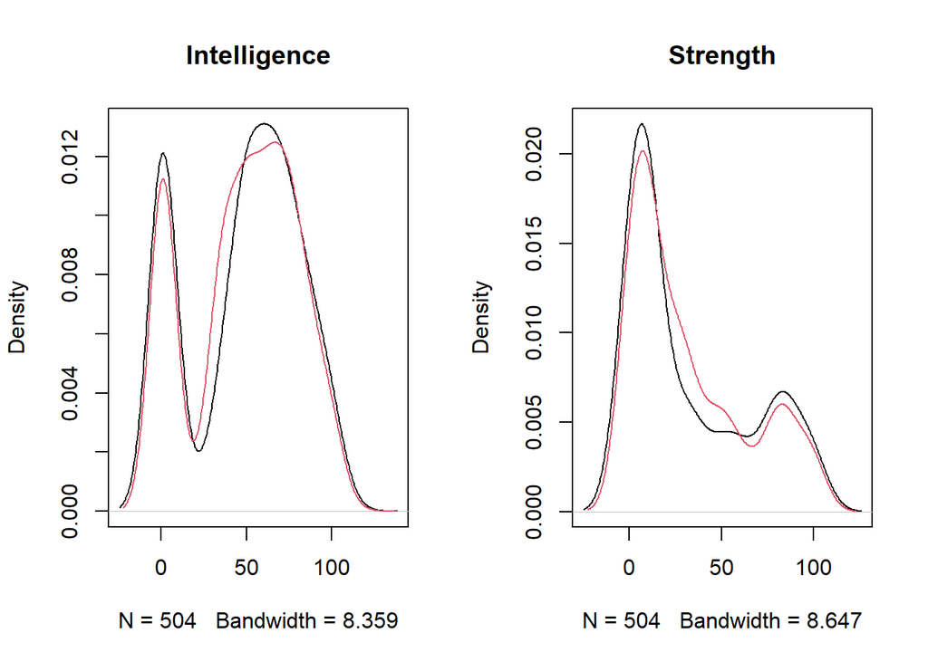

```r
columns<-c("Intelligence","Strength")
impute_arg1  <- mice(Dc_Marvel_StatsInfo[,names(Dc_Marvel_StatsInfo) %in% columns],m = 1,
  maxit = 1, method = "norm.predict",seed = 2018,print=F)

impute_arg <- mice::complete(impute_arg1)
par(mfrow=c(1,2))
plot(density(Dc_Marvel_StatsInfo$Intelligence,na.rm =T),col=1,main="Intelligence")
lines(density(impute_arg$Intelligence),col=2)
plot(density(Dc_Marvel_StatsInfo$Strength,na.rm = T),col=1,main="Strength")
lines(density(impute_arg$Strength),col=2)
```

```r
impute_arg<-round(as.data.frame(impute_arg))

Dc_Marvel_StatsInfo["Intelligence"]<-impute_arg["Intelligence"]
Dc_Marvel_StatsInfo["Strength"]<-impute_arg["Strength"]
```

*Imputación mediante regresión*: N=Antes de la imputación, R=con la imputación.

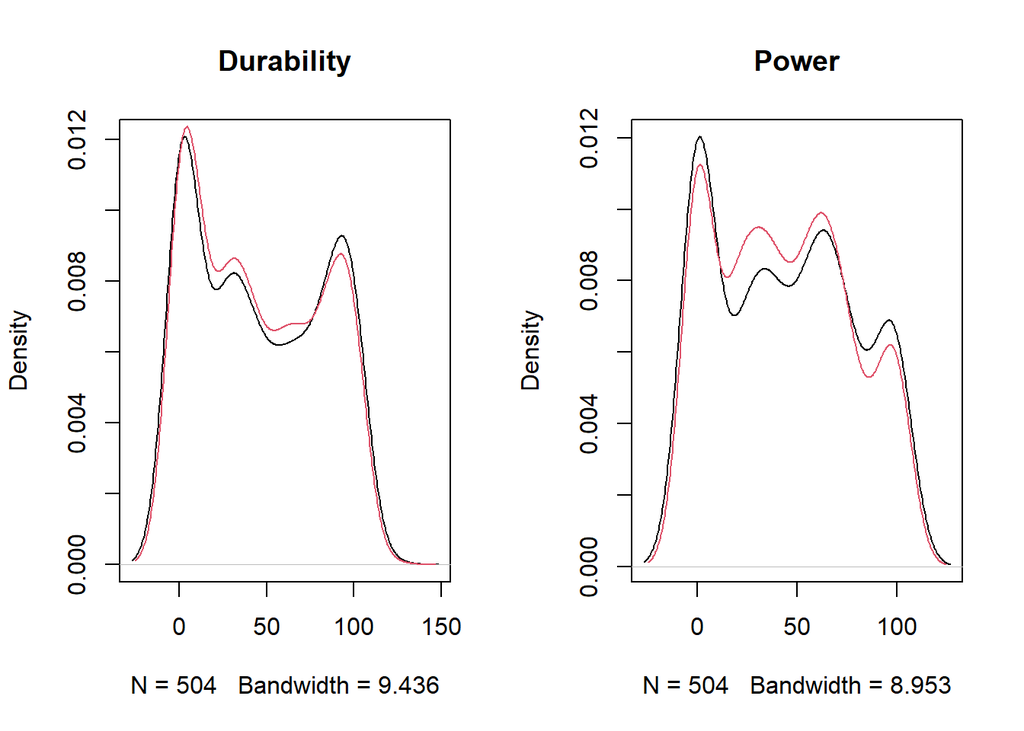

```r
columns<-c("Durability","Power")
impute_arg1  <- mice(Dc_Marvel_StatsInfo[,names(Dc_Marvel_StatsInfo) %in% columns],m = 1,
  maxit = 1, method = "norm.predict",seed = 2018,print=F)

impute_arg <- mice::complete(impute_arg1)
par(mfrow=c(1,2))
plot(density(Dc_Marvel_StatsInfo$Durability,na.rm =T),col=1,main="Durability")
lines(density(impute_arg$Durability),col=2)
plot(density(Dc_Marvel_StatsInfo$Power,na.rm = T),col=1,main="Power")
lines(density(impute_arg$Power),col=2)
```

```r
impute_arg<-round(as.data.frame(impute_arg))

Dc_Marvel_StatsInfo["Durability"]<-impute_arg["Durability"]
Dc_Marvel_StatsInfo["Power"]<-impute_arg["Power"]
```

*Imputación mediante regresión*: N=Antes de la imputación, R=con la imputación.

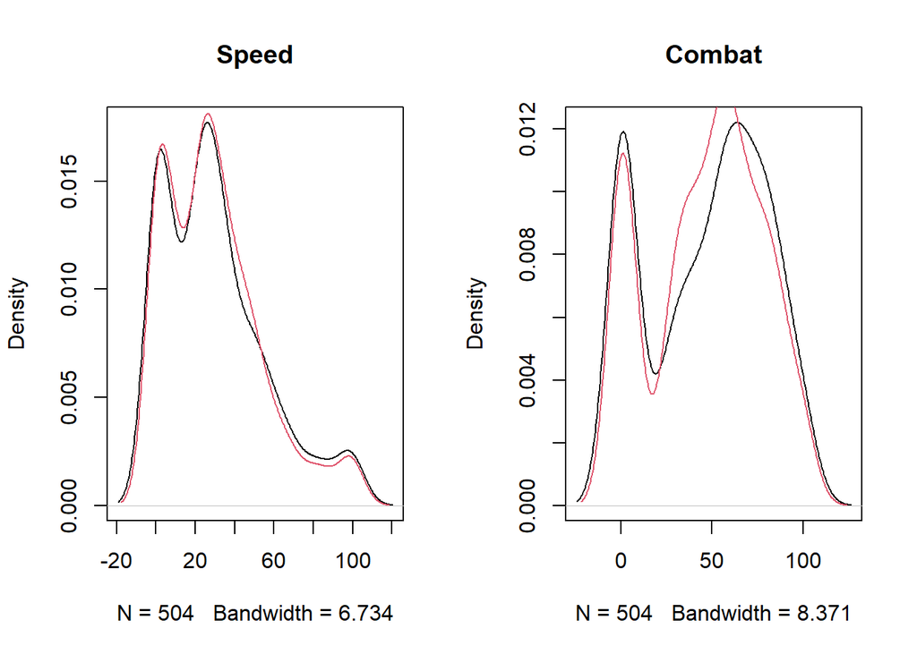

```r
columns<-c("Speed","Combat")
impute_arg1  <- mice(Dc_Marvel_StatsInfo[,names(Dc_Marvel_StatsInfo) %in% columns],m = 1,
  maxit = 1, method = "norm.predict",seed = 2018,print=F)

impute_arg <- mice::complete(impute_arg1)
par(mfrow=c(1,2))
plot(density(Dc_Marvel_StatsInfo$Speed,na.rm =T),col=1,main="Speed")
lines(density(impute_arg$Speed),col=2)
plot(density(Dc_Marvel_StatsInfo$Combat,na.rm = T),col=1,main="Combat")
lines(density(impute_arg$Combat),col=2)
```

```r
impute_arg<-round(as.data.frame(impute_arg))

Dc_Marvel_StatsInfo["Speed"]<-impute_arg["Speed"]
Dc_Marvel_StatsInfo["Combat"]<-impute_arg["Combat"]
```

- Después de haber imputado y eliminado algunas columnas. Verificamos que nuestra nueva base de datos no tiene columnas con NA.

```r
colSums(is.na(Dc_Marvel_StatsInfo))
```

```
##         Name       Gender    Eye.color         Race   Hair.color       Height
##            0            0            0            0            0            0
##    Publisher  Alignment.x       Weight Intelligence     Strength        Speed
##            0            0            0            0            0            0
##   Durability        Power       Combat
##            0            0            0
```